# 04 V2 实验报告

**用途**：汇总 V2 的稳健性、效率、错误类型和扩展任务结果，作为第二版分析报告。  
**定位**：这不是 V1 结论的覆盖版，而是独立的 V2 报告壳。

## 摘要

本报告当前优先回答五个 V2 问题：

1. 将重复数从 3 提高到 10 后，16K / 32K 的结果是否更稳定
2. `style_aligned` / `numeric_confusable` / `multi_key` 三类 needle 的难度排序是什么
3. 哪个模型在“准确率 - 输出 token - 单位成本”三维上更均衡
4. `multi_hop`（事实分散嵌入长文）是否已经接入并形成可分析结果
5. badcase taxonomy 能否把“统计结果”推进成“可指导优化”的评测资产

当前已经出现四个值得前置到结论区的强信号：

- `numeric_confusable` 是平均最难的变体，说明近似数字 / 字符串干扰比 style 对齐或多 key 干扰更容易击穿检索稳定性。
- DeepSeek-V3 (API: `deepseek-chat`) 的最大问题不是“找不到”，而是“输出冗余但包含正确答案”；这类 EM-only miss 已经成为当前最常见 badcase。
- **Kimi (Moonshot, API: `moonshot-v1-128k`) 主口径用 `eval_valid` 有效样本**：350 格中 **31 格**因 haystack 含政治经济类文本触发 Moonshot **content_filter**（平台审核，重试无效），**不计入模型能力**；有效 **319 格 Contains ≈ 94.4%**。全量 350 格（含审核失败）仅作覆盖度参考。
- `multi_hop` 已升级为“把推理事实分散嵌入 ~8000 字符长文”的真正长上下文多跳（约 32 条/模型，3 个模型各 32 条）。Kimi 在 3-hop 上 Contains=0%，是多步综合的明显短板。最显著的信号是 **3-hop 准确率相对 2-hop 出现断崖**，说明长距离、多步骤的信息综合仍是当前模型的薄弱环节。

本文后续统一使用“展示名（API 名）”格式：DeepSeek-V3 (API: `deepseek-chat`)、Kimi (Moonshot, API: `moonshot-v1-128k`)、Qwen-Long (API: `qwen-long`)。

```python
import sys
from pathlib import Path
import importlib

PROJECT_ROOT = Path.cwd().resolve()
if PROJECT_ROOT.name == 'v2' and PROJECT_ROOT.parent.name == 'notebooks':
    PROJECT_ROOT = PROJECT_ROOT.parents[1]
elif PROJECT_ROOT.name == 'notebooks':
    PROJECT_ROOT = PROJECT_ROOT.parent
if str(PROJECT_ROOT) not in sys.path:
    sys.path.insert(0, str(PROJECT_ROOT))

import pandas as pd
import matplotlib
import matplotlib.pyplot as plt
from IPython.display import Image, display as ipy_display

import src.metrics_v2 as metrics_v2_module

importlib.reload(metrics_v2_module)

from src.metrics_v2 import (
    attach_badcase_taxonomy,
    attach_call_status,
    filter_eval_valid,
    is_api_failure,
    summarize_badcase_taxonomy,
    summarize_call_status,
    summarize_v2,
    summarize_variant_matrix,
)

MODEL_DISPLAY_NAMES = {
    'deepseek': 'DeepSeek-V3 (API: deepseek-chat)',
    'kimi': 'Kimi (Moonshot, API: moonshot-v1-128k)',
    'kimi26': 'Kimi 2.6 (API: kimi2.6-320K)',
    'qwen': 'Qwen-Long (API: qwen-long)',
}

BADCASE_DISPLAY_ORDER = [
    '找到了附近信息但抽错目标值',
    '被相似数字干扰',
    '深层位置召回失败',
    '输出冗余但包含正确答案',
    '多 key 条件下定位失败',
    '未作答或信息未命中',
]


def format_model_name(model_key):
    if pd.isna(model_key):
        return model_key
    return MODEL_DISPLAY_NAMES.get(str(model_key), str(model_key))



def with_model_labels(frame, column='model'):
    if frame.empty or column not in frame.columns:
        return frame.copy()
    labeled = frame.copy()
    labeled[column] = labeled[column].apply(format_model_name)
    return labeled


matplotlib.rcParams['font.sans-serif'] = ['PingFang SC', 'Hiragino Sans GB', 'Microsoft YaHei', 'SimHei', 'Arial Unicode MS']
matplotlib.rcParams['axes.unicode_minus'] = False

processed_dir = PROJECT_ROOT / 'results/v2/processed'
scored_path = processed_dir / 'scored_results.csv'
dataset_path = PROJECT_ROOT / 'data/processed/v2/niah_dataset.jsonl'
multihop_dataset_path = PROJECT_ROOT / 'data/processed/v2/multihop_dataset.jsonl'
figures_dir = PROJECT_ROOT / 'results/v2/figures'

if scored_path.exists():
    df = pd.read_csv(scored_path)
    if 'task' not in df.columns:
        df['task'] = 'niah'
    df['task'] = df['task'].fillna('niah')
    df = attach_badcase_taxonomy(df)

    dataset_df = pd.read_json(dataset_path, lines=True) if dataset_path.exists() else pd.DataFrame()
    multihop_dataset_df = pd.read_json(multihop_dataset_path, lines=True) if multihop_dataset_path.exists() else pd.DataFrame()

    niah_df = df[df['task'] == 'niah'].copy()
    multihop_df = df[df['task'] == 'multi_hop'].copy()

    niah_df = attach_call_status(niah_df)
    niah_valid_df = filter_eval_valid(niah_df)
    model_summary = summarize_v2(niah_valid_df) if not niah_valid_df.empty else pd.DataFrame()
    model_summary_all = summarize_v2(niah_df) if not niah_df.empty else pd.DataFrame()
    call_status_summary = summarize_call_status(niah_df) if not niah_df.empty else pd.DataFrame()
    variant_summary = summarize_variant_matrix(niah_valid_df) if not niah_valid_df.empty else pd.DataFrame()
    length_summary = summarize_v2(niah_valid_df, group_cols=['model', 'context_length']) if not niah_valid_df.empty else pd.DataFrame()
    models = sorted(df['model'].dropna().unique().tolist())
    model_labels = [format_model_name(model) for model in models]
    variants = sorted(niah_df['variant'].dropna().unique().tolist()) if 'variant' in niah_df.columns else []
    domains = sorted(niah_df['domain'].dropna().unique().tolist()) if 'domain' in niah_df.columns else []

    expected_niah_per_model = len(dataset_df)
    expected_niah_total = expected_niah_per_model * len(models) if expected_niah_per_model else len(niah_df)
    actual_niah_total = len(niah_df)
    missing_niah_total = expected_niah_total - actual_niah_total
    coverage_pct = actual_niah_total / expected_niah_total * 100 if expected_niah_total else 0.0

    expected_multihop_per_model = len(multihop_dataset_df)
    expected_multihop_total = expected_multihop_per_model * len(models) if expected_multihop_per_model else len(multihop_df)
    actual_multihop_total = len(multihop_df)
    multihop_coverage_pct = actual_multihop_total / expected_multihop_total * 100 if expected_multihop_total else 0.0

    coverage_by_length = (
        niah_df.groupby(['model', 'context_length']).size().unstack(fill_value=0)
        if not niah_df.empty else pd.DataFrame()
        )
    repeat_estimate = (
        int(dataset_df.groupby(['context_length', 'depth_pct']).size().median())
        if not dataset_df.empty else None
        )

    task_summary = summarize_v2(df, group_cols=['model', 'task']) if not df.empty else pd.DataFrame()
    multihop_summary = summarize_v2(multihop_df) if not multihop_df.empty else pd.DataFrame()
    multihop_domain_summary = summarize_v2(multihop_df, group_cols=['model', 'domain']) if not multihop_df.empty else pd.DataFrame()

    niah_badcases = niah_valid_df[niah_valid_df['is_badcase'] == 1].copy()
    niah_badcase_summary = summarize_badcase_taxonomy(niah_valid_df)
    niah_badcase_summary_overall = summarize_badcase_taxonomy(
        niah_valid_df, group_cols=['badcase_taxonomy']
    )
    multihop_badcase_summary = summarize_badcase_taxonomy(multihop_df) if not multihop_df.empty else pd.DataFrame()

    if not niah_badcase_summary.empty:
        niah_badcase_summary['badcase_taxonomy'] = pd.Categorical(
            niah_badcase_summary['badcase_taxonomy'],
            categories=BADCASE_DISPLAY_ORDER,
            ordered=True,
        )
        niah_badcase_summary = niah_badcase_summary.sort_values(['model', 'badcase_taxonomy', 'n'], ascending=[True, True, False])
    if not niah_badcase_summary_overall.empty:
        niah_badcase_summary_overall['badcase_taxonomy'] = pd.Categorical(
            niah_badcase_summary_overall['badcase_taxonomy'],
            categories=BADCASE_DISPLAY_ORDER,
            ordered=True,
        )
        niah_badcase_summary_overall = niah_badcase_summary_overall.sort_values(['badcase_taxonomy', 'n'], ascending=[True, False])

    taxonomy_example_cols = [
        'model', 'variant', 'domain', 'context_length', 'depth_pct',
        'question', 'expected_answer', 'model_response', 'badcase_taxonomy',
        'contains_score', 'em_score',
    ]
    representative_badcases = (
        niah_badcases.sort_values(['badcase_taxonomy', 'model', 'context_length', 'depth_pct'])
        .groupby('badcase_taxonomy', dropna=False)
        .head(3)[taxonomy_example_cols]
        if not niah_badcases.empty else pd.DataFrame(columns=taxonomy_example_cols)
    )
    em_gap_examples = (
        niah_badcases[niah_badcases['badcase_taxonomy'] == '输出冗余但包含正确答案']
        .sort_values(['model', 'context_length', 'depth_pct'])
        [taxonomy_example_cols]
        .head(12)
        if not niah_badcases.empty else pd.DataFrame(columns=taxonomy_example_cols)
    )
    real_task_pilot_df = (
        multihop_dataset_df[
            ['sample_id', 'domain', 'difficulty', 'hops', 'context_length', 'question', 'answer']
        ].rename(columns={'answer': 'expected_answer'})
        if not multihop_dataset_df.empty else pd.DataFrame()
    )

    if not task_summary.empty:
        task_summary.to_csv(processed_dir / 'summary_by_model_task.csv', index=False, encoding='utf-8-sig')
    if not niah_badcase_summary.empty:
        niah_badcase_summary.to_csv(processed_dir / 'summary_by_model_badcase_taxonomy.csv', index=False, encoding='utf-8-sig')
    if not niah_badcase_summary_overall.empty:
        niah_badcase_summary_overall.to_csv(processed_dir / 'summary_by_badcase_taxonomy.csv', index=False, encoding='utf-8-sig')
    if not representative_badcases.empty:
        representative_badcases.to_csv(processed_dir / 'badcase_examples.csv', index=False, encoding='utf-8-sig')

    print(f'✅ 加载 V2 评分结果: {len(df)} 条，PROJECT_ROOT={PROJECT_ROOT}')
    print(f'   模型: {model_labels}')
    print(f'   NIAH 覆盖率: {coverage_pct:.1f}% ({actual_niah_total}/{expected_niah_total})')
    if repeat_estimate is not None:
        print(f'   估计重复数: {repeat_estimate}')
    if not multihop_df.empty:
        print(f'   multi_hop 结果: {actual_multihop_total}/{expected_multihop_total} ({multihop_coverage_pct:.1f}%)')
    elif not multihop_dataset_df.empty:
        print(f'   multi_hop 数据集已准备: {len(multihop_dataset_df)} 条，当前尚未评测')

    if not call_status_summary.empty:
        print('NIAH 调用状态（eval_valid / content_filter / infra_failed）：')
        print(call_status_summary.to_string(index=False))
        kimi_row = call_status_summary[call_status_summary['model'] == 'kimi']
        if not kimi_row.empty:
            r = kimi_row.iloc[0]
            print(
                f'   Kimi 主口径: eval_valid {int(r["eval_valid"])}/{int(r["n"])}，'
                f'content_filter {int(r["content_filter"])}（平台审核，不计入模型能力）'
            )
    print('   报告主结论基于 eval_valid 有效样本（见 summary_by_model_niah_valid_only.csv）')
else:
    print('⚠️ 请先运行 notebooks/v2/03_analysis_visualization_v2.ipynb 生成 V2 评分结果和图表')
```

```
✅ 加载 V2 评分结果: 1146 条，PROJECT_ROOT=/Users/melody/Desktop/Eval
   模型: ['DeepSeek-V3 (API: deepseek-chat)', 'Kimi (Moonshot, API: moonshot-v1-128k)', 'Qwen-Long (API: qwen-long)']
   NIAH 覆盖率: 100.0% (1050/1050)
   估计重复数: 10
   multi_hop 结果: 96/96 (100.0%)
NIAH 调用状态（eval_valid / content_filter / infra_failed）：
   model   n  eval_valid  content_filter  infra_api_failed  eval_valid_pct  content_filter_pct
deepseek 350         328               0                22            93.7                 0.0
    kimi 350         319              31                 0            91.1                 8.9
    qwen 350         319               0                31            91.1                 0.0
   Kimi 主口径: eval_valid 319/350，content_filter 31（平台审核，不计入模型能力）
   报告主结论基于 eval_valid 有效样本（见 summary_by_model_niah_valid_only.csv）
```

## 1. 实验设置

```python
if scored_path.exists():
    print('实验规模：')
    print(f'  已完成 NIAH 样本数:  {actual_niah_total}')
    print(f'  期望 NIAH 样本数:    {expected_niah_total}')
    print(f'  NIAH 覆盖率:         {coverage_pct:.1f}%')
    print(f'  已完成 multi_hop:    {actual_multihop_total}')
    print(f'  期望 multi_hop:      {expected_multihop_total}')
    print(f'  multi_hop 覆盖率:    {multihop_coverage_pct:.1f}%')
    print(f'  评测模型:            {model_labels}')
    print(f'  变体:                {variants}')
    print(f'  领域:                {domains}')
    print(f'  上下文长度:          {sorted(niah_df["context_length"].dropna().unique().tolist()) if not niah_df.empty else []} chars')
    print(f'  Needle 深度点:       {sorted(niah_df["depth_pct"].dropna().unique().tolist()) if not niah_df.empty else []}%')
    print(f'  task:                {sorted(df["task"].dropna().unique().tolist())}')
    if repeat_estimate is not None:
        print(f'  估计重复数:          {repeat_estimate}')
    if not coverage_by_length.empty:
        coverage_by_length_display = coverage_by_length.rename(index=format_model_name)
        print('\n当前覆盖数（model x context_length）：')
        print(coverage_by_length_display.to_string())
    if missing_niah_total > 0:
        print(f'\n⚠️ 当前仍缺少 {missing_niah_total} 条 NIAH 结果，报告只能作为趋势版。')
```

```
实验规模：
  已完成 NIAH 样本数:  1050
  期望 NIAH 样本数:    1050
  NIAH 覆盖率:         100.0%
  已完成 multi_hop:    96
  期望 multi_hop:      96
  multi_hop 覆盖率:    100.0%
  评测模型:            ['DeepSeek-V3 (API: deepseek-chat)', 'Kimi (Moonshot, API: moonshot-v1-128k)', 'Qwen-Long (API: qwen-long)']
  变体:                ['multi_key', 'numeric_confusable', 'style_aligned']
  领域:                ['finance', 'healthcare', 'logistics', 'manufacturing', 'retail']
  上下文长度:          [2000, 4000, 8000, 16000, 32000] chars
  Needle 深度点:       [0.0, 10.0, 25.0, 50.0, 75.0, 90.0, 100.0]%
  task:                ['multi_hop', 'niah']
  估计重复数:          10

当前覆盖数（model x context_length）：
context_length                          2000   4000   8000   16000  32000
model
DeepSeek-V3 (API: deepseek-chat)           70     70     70     70     70
Kimi (Moonshot, API: moonshot-v1-128k)     70     70     70     70     70
Qwen-Long (API: qwen-long)                 70     70     70     70     70
```

## 2. 结果概览

```python
if scored_path.exists() and not model_summary.empty:
    display_cols = [
        'model', 'n', 'em_pct', 'contains_pct',
        'contains_ci_low_pct', 'contains_ci_high_pct',
        'avg_latency_s', 'avg_response_chars', 'avg_completion_tokens',
        'cost_per_contains_hit_cny', 'contains_per_1k_output_tokens',
        ]
    print('模型级摘要：')
    model_summary_display = with_model_labels(
        model_summary[display_cols].sort_values('contains_pct', ascending=False)
    )
    display(model_summary_display)

    best_contains = model_summary.sort_values(['contains_pct', 'contains_ci_low_pct'], ascending=False).iloc[0]
    cheapest = model_summary.sort_values('cost_per_contains_hit_cny', ascending=True).iloc[0]
    shortest = model_summary.sort_values('avg_completion_tokens', ascending=True).iloc[0]

    print('\n快速结论：')
    print(f'  准确率最强: {format_model_name(best_contains["model"])}，Contains={best_contains["contains_pct"]:.1f}%')
    print(f'  单位命中成本最低: {format_model_name(cheapest["model"])}，{cheapest["cost_per_contains_hit_cny"]:.4f} CNY / hit')
    print(f'  输出最短: {format_model_name(shortest["model"])}，平均 completion={shortest["avg_completion_tokens"]:.1f} tokens')
```

```
模型级摘要：
```

|  | model | n | em_pct | contains_pct | contains_ci_low_pct | contains_ci_high_pct | avg_latency_s | avg_response_chars | avg_completion_tokens | cost_per_contains_hit_cny | contains_per_1k_output_tokens |
| --- | --- | --- | --- | --- | --- | --- | --- | --- | --- | --- | --- |
| 0 | DeepSeek-V3 (API: deepseek-chat) | 328 | 65.2 | 96.6 | 94.1 | 98.1 | 0.78 | 6.5 | 5.1 | 0.0057 | 227.70 |
| 1 | Kimi (Moonshot, API: moonshot-v1-128k) | 319 | 89.7 | 94.4 | 91.3 | 96.4 | 2.25 | 6.8 | 6.8 | 0.6388 | 154.47 |
| 2 | Qwen-Long (API: qwen-long) | 319 | 87.8 | 89.3 | 85.5 | 92.3 | 7.83 | 6.6 | 6.1 | 0.0397 | 179.95 |

```
快速结论：
  准确率最强: DeepSeek-V3 (API: deepseek-chat)，Contains=96.6%
  单位命中成本最低: DeepSeek-V3 (API: deepseek-chat)，0.0057 CNY / hit
  输出最短: DeepSeek-V3 (API: deepseek-chat)，平均 completion=5.1 tokens
```

## 3. 变体难度与稳定性

```python
if scored_path.exists() and not variant_summary.empty:
    print('模型 x 变体摘要：')
    variant_summary_display = with_model_labels(
        variant_summary[
            [
                'model', 'variant', 'n', 'contains_pct',
                'contains_ci_low_pct', 'contains_ci_high_pct',
                'avg_completion_tokens', 'cost_per_contains_hit_cny',
            ]
        ].sort_values(['variant', 'contains_pct'], ascending=[True, False])
    )
    display(variant_summary_display)

    variant_pivot = (
        variant_summary.assign(model=variant_summary['model'].apply(format_model_name))
        .pivot(index='model', columns='variant', values='contains_pct')
        .round(1)
    )
    print('变体准确率矩阵 (%)：')
    display(variant_pivot)

    stability_focus = length_summary[length_summary['context_length'].isin([16000, 32000])].copy()
    if not stability_focus.empty:
        print('16K / 32K 稳定性观察：')
        stability_focus_display = with_model_labels(
            stability_focus[
                [
                    'model', 'context_length', 'n', 'contains_pct',
                    'contains_ci_low_pct', 'contains_ci_high_pct',
                    'avg_completion_tokens', 'cost_per_contains_hit_cny',
                ]
            ].sort_values(['context_length', 'contains_pct'], ascending=[True, False])
        )
        display(stability_focus_display)

    if not task_summary.empty and 'multi_hop' in task_summary['task'].values:
        print('扩展任务摘要：')
        display(with_model_labels(task_summary[task_summary['task'] == 'multi_hop']))
```

```
模型 x 变体摘要：
```

|  | model | variant | n | contains_pct | contains_ci_low_pct | contains_ci_high_pct | avg_completion_tokens | cost_per_contains_hit_cny |
| --- | --- | --- | --- | --- | --- | --- | --- | --- |
| 0 | DeepSeek-V3 (API: deepseek-chat) | multi_key | 110 | 100.0 | 96.6 | 100.0 | 4.7 | 0.0064 |
| 3 | Kimi (Moonshot, API: moonshot-v1-128k) | multi_key | 110 | 100.0 | 96.6 | 100.0 | 7.4 | 0.6330 |
| 6 | Qwen-Long (API: qwen-long) | multi_key | 110 | 100.0 | 96.6 | 100.0 | 7.5 | 0.0372 |
| 1 | DeepSeek-V3 (API: deepseek-chat) | numeric_confusable | 109 | 89.9 | 82.8 | 94.3 | 6.2 | 0.0057 |
| 4 | Kimi (Moonshot, API: moonshot-v1-128k) | numeric_confusable | 105 | 82.9 | 74.5 | 88.9 | 7.2 | 0.7143 |
| 7 | Qwen-Long (API: qwen-long) | numeric_confusable | 105 | 67.6 | 58.2 | 75.8 | 5.6 | 0.0516 |
| 2 | DeepSeek-V3 (API: deepseek-chat) | style_aligned | 109 | 100.0 | 96.6 | 100.0 | 4.4 | 0.0051 |
| 5 | Kimi (Moonshot, API: moonshot-v1-128k) | style_aligned | 104 | 100.0 | 96.4 | 100.0 | 5.7 | 0.5819 |
| 8 | Qwen-Long (API: qwen-long) | style_aligned | 104 | 100.0 | 96.4 | 100.0 | 5.1 | 0.0342 |

```
变体准确率矩阵 (%)：
```

| variant model | multi_key | numeric_confusable | style_aligned |
| --- | --- | --- | --- |
| DeepSeek-V3 (API: deepseek-chat) | 100.0 | 89.9 | 100.0 |
| Kimi (Moonshot, API: moonshot-v1-128k) | 100.0 | 82.9 | 100.0 |
| Qwen-Long (API: qwen-long) | 100.0 | 67.6 | 100.0 |

```
16K / 32K 稳定性观察：
```

|  | model | context_length | n | contains_pct | contains_ci_low_pct | contains_ci_high_pct | avg_completion_tokens | cost_per_contains_hit_cny |
| --- | --- | --- | --- | --- | --- | --- | --- | --- |
| 8 | Kimi (Moonshot, API: moonshot-v1-128k) | 16000 | 64 | 96.9 | 89.3 | 99.1 | 6.8 | 0.8441 |
| 3 | DeepSeek-V3 (API: deepseek-chat) | 16000 | 64 | 93.8 | 85.0 | 97.5 | 4.8 | 0.0078 |
| 13 | Qwen-Long (API: qwen-long) | 16000 | 64 | 90.6 | 81.0 | 95.6 | 5.9 | 0.0521 |
| 9 | Kimi (Moonshot, API: moonshot-v1-128k) | 32000 | 61 | 100.0 | 94.1 | 100.0 | 6.9 | 1.5534 |
| 4 | DeepSeek-V3 (API: deepseek-chat) | 32000 | 70 | 98.6 | 92.3 | 99.7 | 4.9 | 0.0135 |
| 14 | Qwen-Long (API: qwen-long) | 32000 | 61 | 95.1 | 86.5 | 98.3 | 6.4 | 0.0973 |

```
扩展任务摘要：
```

|  | model | task | n | em_pct | contains_pct | contains_ci_low_pct | contains_ci_high_pct | avg_latency_s | avg_response_chars | avg_completion_tokens | total_cost_cny | cost_per_contains_hit_cny | cost_per_em_hit_cny | contains_per_1k_output_tokens |
| --- | --- | --- | --- | --- | --- | --- | --- | --- | --- | --- | --- | --- | --- | --- |
| 0 | DeepSeek-V3 (API: deepseek-chat) | multi_hop | 32 | 43.8 | 71.9 | 54.6 | 84.4 | 1.36 | 6.9 | 4.2 | 0.1107 | 0.0048 | 0.0079 | 265.40 |
| 2 | Kimi (Moonshot, API: moonshot-v1-128k) | multi_hop | 32 | 50.0 | 62.5 | 45.3 | 77.1 | 1.45 | 7.7 | 5.8 | 10.3397 | 0.5170 | 0.6462 | 161.75 |
| 4 | Qwen-Long (API: qwen-long) | multi_hop | 32 | 68.8 | 75.0 | 57.9 | 86.7 | 0.90 | 4.9 | 4.1 | 0.6243 | 0.0260 | 0.0284 | 215.10 |

## 4. 图表回顾

```
### DeepSeek-V3 (API: deepseek-chat)
```

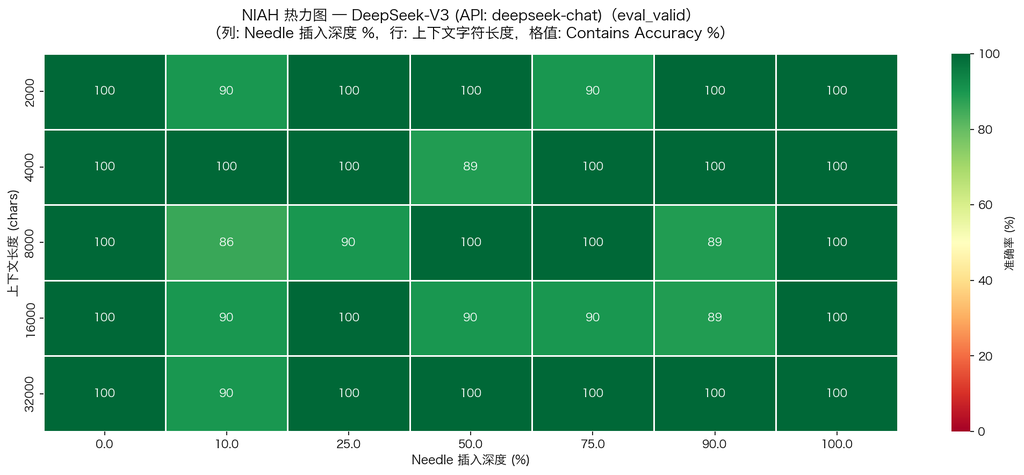

```
### Qwen-Long (API: qwen-long)
```

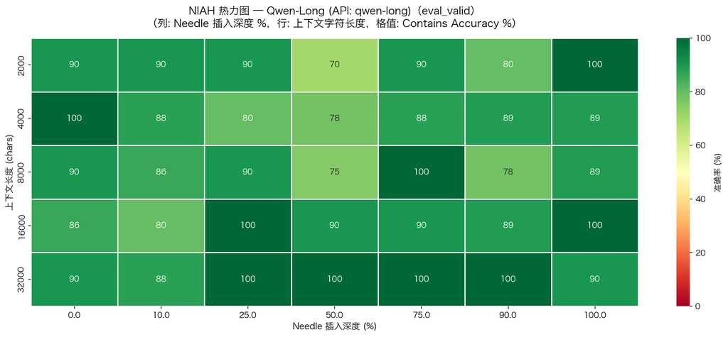

```
### Kimi (Moonshot, API: moonshot-v1-128k)
```

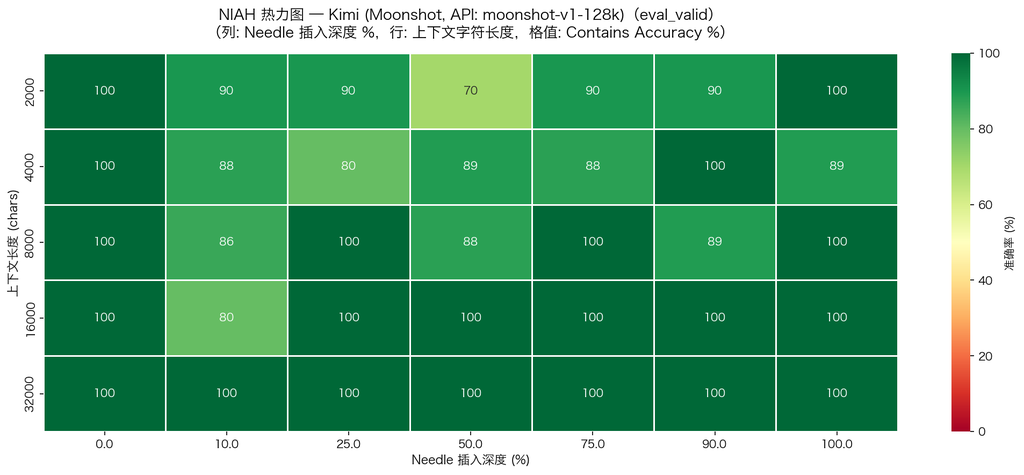

```
### 准确率 vs 上下文长度
```

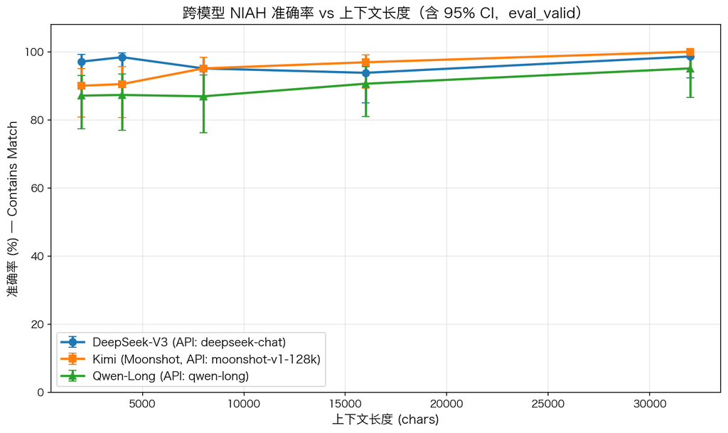

```python
if scored_path.exists():
    for model in niah_df['model'].unique():
        img_path = figures_dir / f'niah_heatmap_{model}.png'
        if img_path.exists():
            print(f'### {format_model_name(model)}')
            ipy_display(Image(str(img_path)))
        else:
            print(f'图片未找到: {img_path}')

    accuracy_img = figures_dir / 'accuracy_by_length_with_ci.png'
    if accuracy_img.exists():
        print('### 准确率 vs 上下文长度')
        ipy_display(Image(str(accuracy_img)))
```

## 5. 效率与位置偏差图

```
### efficiency_tradeoff.png
```

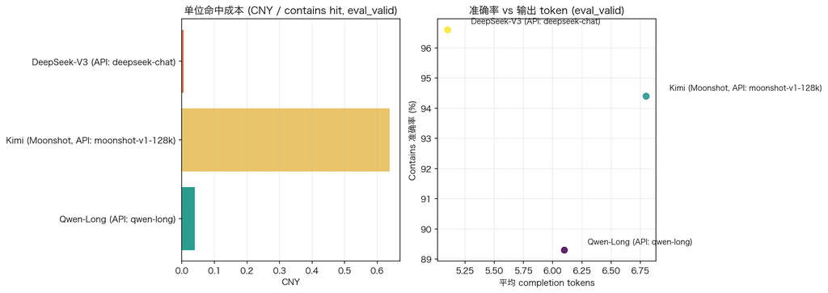

```
### position_bias.png
```

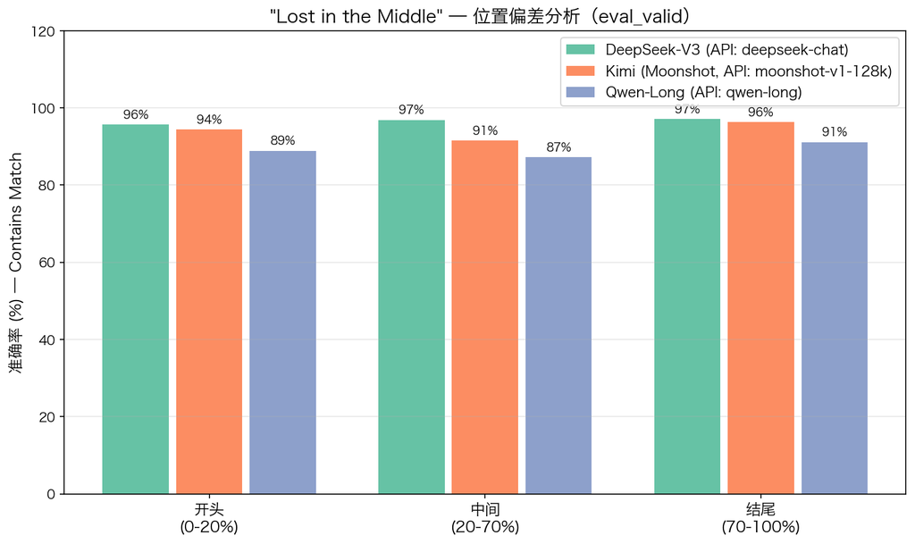

```
### depth_accuracy_curve.png
```

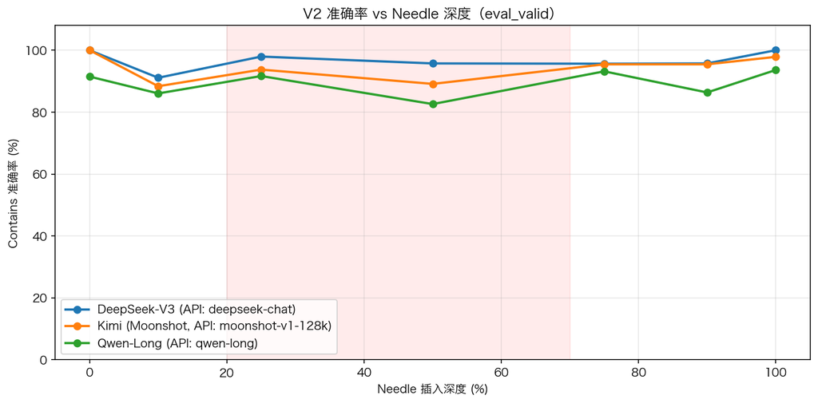

```python
if scored_path.exists():
    for name in ['efficiency_tradeoff.png', 'position_bias.png', 'depth_accuracy_curve.png']:
        img_path = figures_dir / name
        if img_path.exists():
            print(f'### {name}')
            ipy_display(Image(str(img_path)))
        else:
            print(f'图片未找到: {img_path}')
```

6. Badcase Taxonomy

```
整体 badcase taxonomy（eval_valid 主口径，含 Contains miss 与 EM-only miss）：
```

|  | badcase_taxonomy | n | share_pct |
| --- | --- | --- | --- |
| 1 | 输出冗余但包含正确答案 | 123 | 66.1 |
| 0 | 被相似数字干扰 | 63 | 33.9 |

```
按模型拆分：
```

| badcase_taxonomy model | 被相似数字干扰 | 输出冗余但包含正确答案 |
| --- | --- | --- |
| DeepSeek-V3 (API: deepseek-chat) | 11 | 103 |
| Kimi (Moonshot, API: moonshot-v1-128k) | 18 | 15 |
| Qwen-Long (API: qwen-long) | 34 | 5 |

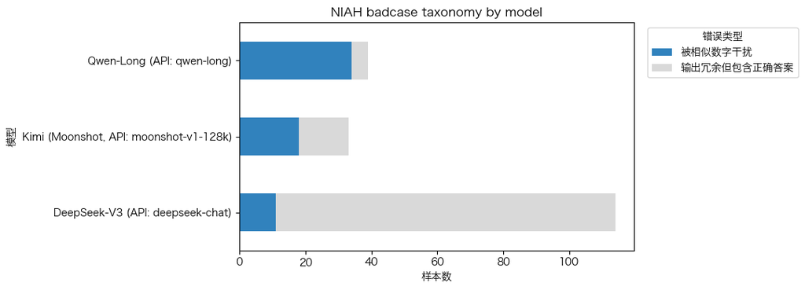

```
每类 1 条代表性失败样本：
```

|  | badcase_taxonomy | model | variant | question | expected_answer | model_response |
| --- | --- | --- | --- | --- | --- | --- |
| 11 | 被相似数字干扰 | DeepSeek-V3 (API: deepseek-chat) | numeric_confusable | 区域配送的 SLA 指标是多少？ | 92.1% | 24小时履约率。 |
| 9 | 输出冗余但包含正确答案 | DeepSeek-V3 (API: deepseek-chat) | multi_key | 院务会最终批准的日间手术中心新增床位数是多少？ | 42张 | 42张。 |

```
EM miss 但 Contains hit 的典型样本：
```

|  | model | variant | question | expected_answer | model_response |
| --- | --- | --- | --- | --- | --- |
| 9 | DeepSeek-V3 (API: deepseek-chat) | multi_key | 院务会最终批准的日间手术中心新增床位数是多少？ | 42张 | 42张。 |
| 13 | DeepSeek-V3 (API: deepseek-chat) | style_aligned | 公司 2025 年资本开支上限是多少？ | 18.6亿元 | 18.6亿元。 |
| 16 | DeepSeek-V3 (API: deepseek-chat) | style_aligned | 急诊药房重点监控药品的库存周转天数是多少？ | 6.5天 | 6.5天。 |
| 19 | DeepSeek-V3 (API: deepseek-chat) | style_aligned | 急诊药房重点监控药品的库存周转天数是多少？ | 6.5天 | 6.5天。 |
| 27 | DeepSeek-V3 (API: deepseek-chat) | numeric_confusable | 区域配送的 SLA 指标是多少？ | 92.1% | 92.1% 的 24 小时履约率。 |
| 32 | DeepSeek-V3 (API: deepseek-chat) | style_aligned | 急诊药房重点监控药品的库存周转天数是多少？ | 6.5天 | 6.5天。 |
| 33 | DeepSeek-V3 (API: deepseek-chat) | numeric_confusable | 区域配送的 SLA 指标是多少？ | 92.1% | 92.1% 的 24 小时履约率。 |
| 35 | DeepSeek-V3 (API: deepseek-chat) | style_aligned | 本季度封装段一次良率目标是多少？ | 98.2% | 98.2%。 |

7. multi-hop（嵌入长文）正式结果

```
任务级对比：
```

|  | model | task | n | em_pct | contains_pct | contains_ci_low_pct | contains_ci_high_pct | avg_latency_s | avg_response_chars | avg_completion_tokens | total_cost_cny | cost_per_contains_hit_cny | cost_per_em_hit_cny | contains_per_1k_output_tokens |
| --- | --- | --- | --- | --- | --- | --- | --- | --- | --- | --- | --- | --- | --- | --- |
| 4 | Qwen-Long (API: qwen-long) | multi_hop | 32 | 68.8 | 75.0 | 57.9 | 86.7 | 0.90 | 4.9 | 4.1 | 0.6243 | 0.0260 | 0.0284 | 215.10 |
| 0 | DeepSeek-V3 (API: deepseek-chat) | multi_hop | 32 | 43.8 | 71.9 | 54.6 | 84.4 | 1.36 | 6.9 | 4.2 | 0.1107 | 0.0048 | 0.0079 | 265.40 |
| 2 | Kimi (Moonshot, API: moonshot-v1-128k) | multi_hop | 32 | 50.0 | 62.5 | 45.3 | 77.1 | 1.45 | 7.7 | 5.8 | 10.3397 | 0.5170 | 0.6462 | 161.75 |
| 1 | DeepSeek-V3 (API: deepseek-chat) | niah | 350 | 61.1 | 90.6 | 87.1 | 93.2 | 0.73 | 6.1 | 4.8 | 1.8211 | 0.0057 | 0.0085 | 213.38 |
| 3 | Kimi (Moonshot, API: moonshot-v1-128k) | niah | 350 | 81.7 | 86.0 | 82.0 | 89.2 | 2.05 | 6.2 | 6.2 | 192.2936 | 0.6388 | 0.6724 | 140.79 |
| 5 | Qwen-Long (API: qwen-long) | niah | 350 | 80.0 | 81.4 | 77.0 | 85.2 | 7.14 | 6.0 | 5.5 | 11.3116 | 0.0397 | 0.0404 | 164.01 |

| task model | multi_hop | niah |
| --- | --- | --- |
| DeepSeek-V3 (API: deepseek-chat) | 71.9 | 90.6 |
| Kimi (Moonshot, API: moonshot-v1-128k) | 62.5 | 86.0 |
| Qwen-Long (API: qwen-long) | 75.0 | 81.4 |

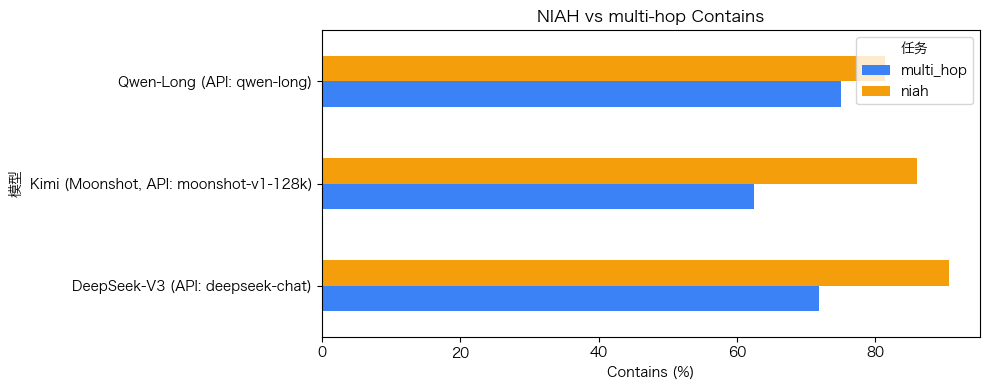

```
multi_hop 汇总：
```

|  | model | n | em_pct | contains_pct | contains_ci_low_pct | contains_ci_high_pct | avg_latency_s | avg_response_chars | avg_completion_tokens | total_cost_cny | cost_per_contains_hit_cny | cost_per_em_hit_cny | contains_per_1k_output_tokens |
| --- | --- | --- | --- | --- | --- | --- | --- | --- | --- | --- | --- | --- | --- |
| 0 | DeepSeek-V3 (API: deepseek-chat) | 32 | 43.8 | 71.9 | 54.6 | 84.4 | 1.36 | 6.9 | 4.2 | 0.1107 | 0.0048 | 0.0079 | 265.40 |
| 1 | Kimi (Moonshot, API: moonshot-v1-128k) | 32 | 50.0 | 62.5 | 45.3 | 77.1 | 1.45 | 7.7 | 5.8 | 10.3397 | 0.5170 | 0.6462 | 161.75 |
| 2 | Qwen-Long (API: qwen-long) | 32 | 68.8 | 75.0 | 57.9 | 86.7 | 0.90 | 4.9 | 4.1 | 0.6243 | 0.0260 | 0.0284 | 215.10 |

```
按领域拆分：
```

|  | model | domain | n | em_pct | contains_pct | contains_ci_low_pct | contains_ci_high_pct |
| --- | --- | --- | --- | --- | --- | --- | --- |
| 0 | DeepSeek-V3 (API: deepseek-chat) | credit_cs | 7 | 28.6 | 71.4 | 35.9 | 91.8 |
| 5 | Kimi (Moonshot, API: moonshot-v1-128k) | credit_cs | 7 | 57.1 | 71.4 | 35.9 | 91.8 |
| 10 | Qwen-Long (API: qwen-long) | credit_cs | 7 | 57.1 | 71.4 | 35.9 | 91.8 |
| 1 | DeepSeek-V3 (API: deepseek-chat) | finance | 7 | 14.3 | 71.4 | 35.9 | 91.8 |
| 6 | Kimi (Moonshot, API: moonshot-v1-128k) | finance | 7 | 57.1 | 71.4 | 35.9 | 91.8 |
| 11 | Qwen-Long (API: qwen-long) | finance | 7 | 57.1 | 71.4 | 35.9 | 91.8 |
| 2 | DeepSeek-V3 (API: deepseek-chat) | healthcare | 6 | 33.3 | 50.0 | 18.8 | 81.2 |
| 7 | Kimi (Moonshot, API: moonshot-v1-128k) | healthcare | 6 | 50.0 | 50.0 | 18.8 | 81.2 |
| 12 | Qwen-Long (API: qwen-long) | healthcare | 6 | 50.0 | 50.0 | 18.8 | 81.2 |
| 3 | DeepSeek-V3 (API: deepseek-chat) | manufacturing | 6 | 66.7 | 83.3 | 43.6 | 97.0 |
| 13 | Qwen-Long (API: qwen-long) | manufacturing | 6 | 83.3 | 83.3 | 43.6 | 97.0 |
| 8 | Kimi (Moonshot, API: moonshot-v1-128k) | manufacturing | 6 | 33.3 | 50.0 | 18.8 | 81.2 |
| 14 | Qwen-Long (API: qwen-long) | retail | 6 | 100.0 | 100.0 | 61.0 | 100.0 |
| 4 | DeepSeek-V3 (API: deepseek-chat) | retail | 6 | 83.3 | 83.3 | 43.6 | 97.0 |
| 9 | Kimi (Moonshot, API: moonshot-v1-128k) | retail | 6 | 50.0 | 66.7 | 30.0 | 90.3 |

```
按推理跳数（hops）拆分 Contains (%)：
```

| hops model | 2.0 | 3.0 |
| --- | --- | --- |
| DeepSeek-V3 (API: deepseek-chat) | 81.5 | 20.0 |
| Kimi (Moonshot, API: moonshot-v1-128k) | 74.1 | 0.0 |
| Qwen-Long (API: qwen-long) | 81.5 | 40.0 |

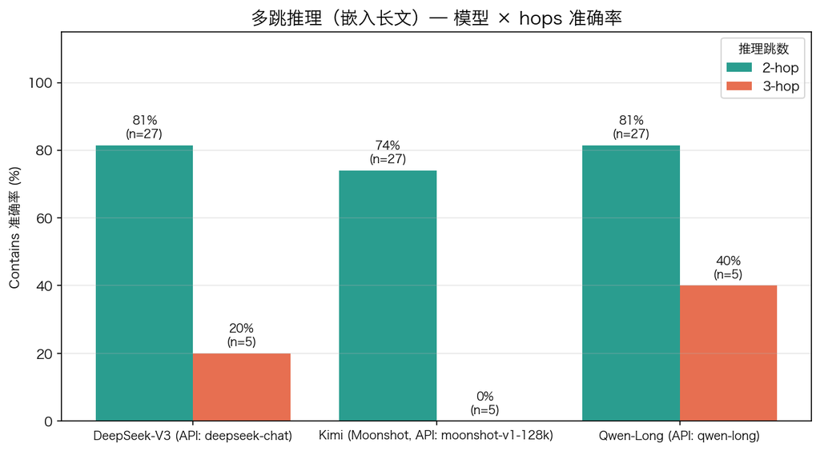

```
multi_hop badcase taxonomy：
```

|  | model | badcase_taxonomy | n | contains_failures | em_only_misses | share_pct |
| --- | --- | --- | --- | --- | --- | --- |
| 4 | Kimi (Moonshot, API: moonshot-v1-128k) | 多跳推理链条或计算失败 | 12 | 12 | 0 | 27.3 |
| 1 | DeepSeek-V3 (API: deepseek-chat) | 多跳推理链条或计算失败 | 9 | 9 | 0 | 20.5 |
| 7 | Qwen-Long (API: qwen-long) | 多跳推理链条或计算失败 | 8 | 8 | 0 | 18.2 |
| 2 | DeepSeek-V3 (API: deepseek-chat) | 输出冗余但包含正确答案 | 7 | 0 | 7 | 15.9 |
| 0 | DeepSeek-V3 (API: deepseek-chat) | judge 语义正确（字面不匹配） | 2 | 0 | 2 | 4.5 |
| 3 | Kimi (Moonshot, API: moonshot-v1-128k) | judge 语义正确（字面不匹配） | 2 | 0 | 2 | 4.5 |
| 5 | Kimi (Moonshot, API: moonshot-v1-128k) | 输出冗余但包含正确答案 | 2 | 0 | 2 | 4.5 |
| 6 | Qwen-Long (API: qwen-long) | judge 语义正确（字面不匹配） | 2 | 0 | 2 | 4.5 |

```
multi_hop 逐条结果（节选）：
```

|  | model | domain | difficulty | hops | question | expected_answer | model_response | contains_score | badcase_taxonomy |
| --- | --- | --- | --- | --- | --- | --- | --- | --- | --- |
| 725 | DeepSeek-V3 (API: deepseek-chat) | credit_cs | medium | 2.0 | 客户一年大致需支付多少利息？ | 7200元 | 7200元 | 1 | 多跳推理链条或计算失败 |
| 726 | DeepSeek-V3 (API: deepseek-chat) | credit_cs | medium | 2.0 | 该客户预计可获得多少授信额度？ | 10万元 | 10万元。 | 1 | 输出冗余但包含正确答案 |
| 727 | DeepSeek-V3 (API: deepseek-chat) | credit_cs | hard | 3.0 | 客户分期期间共需支付多少手续费？ | 8640元 | 客户分期期间共需支付864元手续费。 | 0 | 多跳推理链条或计算失败 |
| 728 | DeepSeek-V3 (API: deepseek-chat) | credit_cs | medium | 2.0 | 预计哪天放款？ | 周四 | 申请后3个工作日。 | 0 | 多跳推理链条或计算失败 |
| 729 | DeepSeek-V3 (API: deepseek-chat) | credit_cs | hard | 2.0 | 该客户应被判定为什么风险等级？ | 高风险 | 高风险 | 1 | 多跳推理答案偏移 |
| 730 | DeepSeek-V3 (API: deepseek-chat) | credit_cs | hard | 2.0 | 客户当前能否申请信用贷 A？为什么？ | 不能，因为公积金缴存未满1年 | 不能，因为公积金连续缴存未满1年。 | 1 | judge 语义正确（字面不匹配） |
| 731 | DeepSeek-V3 (API: deepseek-chat) | credit_cs | medium | 2.0 | 提前结清需支付多少违约金？ | 800元 | 800元。 | 1 | 输出冗余但包含正确答案 |
| 700 | DeepSeek-V3 (API: deepseek-chat) | finance | medium | 2.0 | 按照计划，2025 年第一季度对应的研发费用预算约是多少？ | 9.45亿元 | 126亿元 × 7.5% = 9.45亿元。 | 1 | 输出冗余但包含正确答案 |
| 701 | DeepSeek-V3 (API: deepseek-chat) | finance | hard | 2.0 | 公司 2025 年的净利润目标金额约为多少？ | 40亿元 | 40亿元。 | 1 | 输出冗余但包含正确答案 |
| 702 | DeepSeek-V3 (API: deepseek-chat) | finance | hard | 3.0 | 按上述口径，本年销售费用约为多少？ | 12亿元 | 30亿元 | 0 | 多跳推理链条或计算失败 |
| 703 | DeepSeek-V3 (API: deepseek-chat) | finance | medium | 2.0 | 公司净利润总额约为多少？ | 20亿元 | 20亿元。 | 1 | 输出冗余但包含正确答案 |
| 704 | DeepSeek-V3 (API: deepseek-chat) | finance | medium | 2.0 | 公司第一季度季报最晚应在哪天前披露？ | 5月15日 | 3月31日 | 0 | 多跳推理链条或计算失败 |
| 705 | DeepSeek-V3 (API: deepseek-chat) | finance | hard | 2.0 | 公司下调全年营收指引的主要原因是什么？ | 海外市场需求疲软导致订单下滑 | 海外市场需求疲软。 | 1 | judge 语义正确（字面不匹配） |
| 706 | DeepSeek-V3 (API: deepseek-chat) | finance | medium | 2.0 | 公司的净现金（现金及等价物减去短期借款）为多少？ | 20亿元 | 20亿元 | 1 | 多跳推理链条或计算失败 |
| 713 | DeepSeek-V3 (API: deepseek-chat) | healthcare | hard | 2.0 | 按质控要求，夜班样本最晚应在什么时间前回传结果？ | 23:30 | 19:30完成集中采样后4小时内。 | 0 | 多跳推理链条或计算失败 |
| 714 | DeepSeek-V3 (API: deepseek-chat) | healthcare | medium | 2.0 | 该患者单次最多可领取多少片？ | 60片 | 30片 | 0 | 多跳推理链条或计算失败 |
| 715 | DeepSeek-V3 (API: deepseek-chat) | healthcare | hard | 3.0 | 按规范，本周该病区至少需配备多少名护士？ | 9名 | 10名护士。 | 0 | 多跳推理链条或计算失败 |
| 716 | DeepSeek-V3 (API: deepseek-chat) | healthcare | medium | 2.0 | 该患者单次给药剂量为多少？ | 30毫克 | 30毫克 | 1 | 多跳推理链条或计算失败 |
| 717 | DeepSeek-V3 (API: deepseek-chat) | healthcare | medium | 2.0 | 该患者应被分诊为什么等级？ | 急危 | 急危等级 | 1 | 多跳推理答案偏移 |
| 718 | DeepSeek-V3 (API: deepseek-chat) | healthcare | medium | 2.0 | 当天上午第 5 个号源的预约时间是几点？ | 9:00 | 上午 9:00。 | 1 | 输出冗余但包含正确答案 |

```
本轮 multi-hop 已升级为「事实分散嵌入 ~8000 字符长文」的真正长上下文多跳，共 96 条（约 32 条/模型，覆盖模型 DeepSeek-V3 (API: deepseek-chat), Kimi (Moonshot, API: moonshot-v1-128k), Qwen-Long (API: qwen-long)）。按跳数看：2-hop 79%(n=81)；3-hop 20%(n=15)；3-hop 明显更难。
口径说明：本轮多跳覆盖 DeepSeek-V3 (API: deepseek-chat)、Kimi (Moonshot, API: moonshot-v1-128k)、Qwen-Long (API: qwen-long)；2 个 judge 型样本共 6 个模型回答已通过独立人工裁决表复核。EM 保留严格字面口径，Contains 使用裁决结果。
```

8. 真实任务子集路线（待扩充）

```
真实任务子集仍是路线图（尚未采集真实文档与标注），与上面的合成多跳相互独立：
```

|  | subset | target_samples | design_goal |
| --- | --- | --- | --- |
| 0 | 长文档关键信息抽取 | 12 | 验证模型在长文档里定位并抽取关键数值/时间/实体的能力 |
| 1 | 中文财报 / 研报问答 | 10 | 验证模型能否在多指标并列时锁定目标财务口径 |
| 2 | 多段政策文本比对 | 8 | 验证跨段落条件对齐、例外条款识别和版本差异判断 |
| 3 | 客服知识库长上下文检索问答 | 10 | 验证真实 FAQ / SOP 语料里的检索定位与简洁作答 |

9. 优化建议与数据策略

```
1. numeric_confusable 当前平均 Contains 最低 (80.1%)，说明模型对相似数字 / 相邻口径区分仍弱，下一轮应补更多相似数值干扰样本，并把数字单位、时间、百分比混排进同一段上下文。
2. Kimi 有 31 条 content_filter（Moonshot 平台审核拦截），已从 eval_valid 主口径排除；报告 headline 不应使用含审核失败的 350 行全量平均。
3. Kimi 在 32K eval_valid 样本上 Contains=100.0%，95% CI=[94.1, 100.0]；早期「32K 崩塌」来自余额耗尽（prompt_tokens=0），重跑后已恢复。
4. DeepSeek 的 Contains 明显高于 EM，gap=31.4pp，说明定位能力已经足够，但抽取格式仍不够稳定；下一轮应补格式约束、短答案 extraction-style prompt，以及更多“只返回目标值”的训练样本。
5. multi-hop 已升级为嵌入长文版（约 32 条/模型，当前覆盖 DeepSeek-V3 (API: deepseek-chat)、Kimi (Moonshot, API: moonshot-v1-128k)、Qwen-Long (API: qwen-long)）。当前 judge 样本已人工复核；下一步应扩充 3-hop 与跨领域样本，并为新增开放答案接入可复现的 LLM-as-judge。
6. 当前最常见的 badcase 类型是“输出冗余但包含正确答案”（66.1%）。这意味着后续优化不能只盯整体准确率，还需要把该类样本单独做回归集。
```

```python
from IPython.display import Markdown, display

if scored_path.exists():
    display(Markdown('## 6. Badcase Taxonomy'))
    if not niah_badcase_summary_overall.empty:
        print('整体 badcase taxonomy（eval_valid 主口径，含 Contains miss 与 EM-only miss）：')
        overall_taxonomy_display = niah_badcase_summary_overall.sort_values('n', ascending=False)[['badcase_taxonomy', 'n', 'share_pct']]
        display(overall_taxonomy_display)

        taxonomy_pivot = (
            with_model_labels(niah_badcase_summary[['model', 'badcase_taxonomy', 'n']])
            .pivot(index='model', columns='badcase_taxonomy', values='n')
            .fillna(0)
            .astype(int)
        )
        ordered_cols = [col for col in BADCASE_DISPLAY_ORDER if col in taxonomy_pivot.columns]
        ordered_cols += [col for col in taxonomy_pivot.columns if col not in ordered_cols]
        taxonomy_pivot = taxonomy_pivot[ordered_cols]

        print('按模型拆分：')
        display(taxonomy_pivot)

        if not taxonomy_pivot.empty:
            ax = taxonomy_pivot.plot(kind='barh', stacked=True, figsize=(11, 4), colormap='tab20c')
            ax.set_title('NIAH badcase taxonomy by model')
            ax.set_xlabel('样本数')
            ax.set_ylabel('模型')
            ax.legend(title='错误类型', bbox_to_anchor=(1.02, 1), loc='upper left')
            plt.tight_layout()
            plt.show()

    if not representative_badcases.empty:
        print('每类 1 条代表性失败样本：')
        report_badcase_examples = (
            representative_badcases.groupby('badcase_taxonomy', dropna=False)
            .head(1)[['badcase_taxonomy', 'model', 'variant', 'question', 'expected_answer', 'model_response']]
        )
        display(with_model_labels(report_badcase_examples))

    if not em_gap_examples.empty:
        print('EM miss 但 Contains hit 的典型样本：')
        display(with_model_labels(em_gap_examples[['model', 'variant', 'question', 'expected_answer', 'model_response']].head(8)))

    display(Markdown('## 7. multi-hop（嵌入长文）正式结果'))
    if not task_summary.empty:
        print('任务级对比：')
        task_display = with_model_labels(task_summary).sort_values(['task', 'contains_pct'], ascending=[True, False])
        display(task_display)

        task_pivot = (
            with_model_labels(task_summary[['model', 'task', 'contains_pct']])
            .pivot(index='model', columns='task', values='contains_pct')
            .round(1)
        )
        display(task_pivot)

        if not task_pivot.empty:
            ax = task_pivot.plot(kind='barh', figsize=(10, 4), color=['#3b82f6', '#f59e0b'])
            ax.set_title('NIAH vs multi-hop Contains')
            ax.set_xlabel('Contains (%)')
            ax.set_ylabel('模型')
            ax.legend(title='任务')
            plt.tight_layout()
            plt.show()

    if not multihop_summary.empty:
        mh_models = sorted(multihop_df['model'].dropna().unique().tolist())
        mh_per_model = int(round(len(multihop_df) / max(len(mh_models), 1)))
        mh_hops_acc = (multihop_df.groupby('hops')['contains_score'].mean() * 100)
        mh_hops_n = multihop_df.groupby('hops').size()
        judge_rows = multihop_df[multihop_df['scoring_mode'] == 'judge'] if 'scoring_mode' in multihop_df.columns else pd.DataFrame()
        n_judge_samples = int(judge_rows['sample_id'].nunique()) if not judge_rows.empty else 0
        n_judge_adjudicated = int((judge_rows['judge_status'] == 'adjudicated').sum()) if not judge_rows.empty and 'judge_status' in judge_rows.columns else 0

        print('multi_hop 汇总：')
        display(with_model_labels(multihop_summary))

        if not multihop_domain_summary.empty:
            print('按领域拆分：')
            display(
                with_model_labels(
                    multihop_domain_summary[
                        ['model', 'domain', 'n', 'em_pct', 'contains_pct', 'contains_ci_low_pct', 'contains_ci_high_pct']
                    ].sort_values(['domain', 'contains_pct'], ascending=[True, False])
                )
            )

        print('按推理跳数（hops）拆分 Contains (%)：')
        display(((multihop_df.groupby(['model', 'hops'])['contains_score'].mean() * 100).round(1).unstack()).rename(index=format_model_name))

        if (figures_dir / 'multihop_by_hops.png').exists():
            ipy_display(Image(str(figures_dir / 'multihop_by_hops.png')))

        if not multihop_badcase_summary.empty:
            print('multi_hop badcase taxonomy：')
            display(with_model_labels(multihop_badcase_summary))

        print('multi_hop 逐条结果（节选）：')
        display(
            with_model_labels(
                multihop_df[
                    ['model', 'domain', 'difficulty', 'hops', 'question', 'expected_answer', 'model_response', 'contains_score', 'badcase_taxonomy']
                ].sort_values(['model', 'domain']).head(20)
            )
        )
        hops_desc = '；'.join(f'{int(h)}-hop {mh_hops_acc[h]:.0f}%(n={int(mh_hops_n[h])})' for h in sorted(mh_hops_acc.index))
        print(
            f'本轮 multi-hop 已升级为「事实分散嵌入 ~8000 字符长文」的真正长上下文多跳，共 {len(multihop_df)} 条'
            f'（约 {mh_per_model} 条/模型，覆盖模型 {", ".join(format_model_name(m) for m in mh_models)}）。'
            f'按跳数看：{hops_desc}；3-hop 明显更难。'
        )
        print(
            f'口径说明：本轮多跳覆盖 {"、".join(format_model_name(m) for m in mh_models)}；'
            f'{n_judge_samples} 个 judge 型样本共 {n_judge_adjudicated} 个模型回答已通过独立人工裁决表复核。'
            'EM 保留严格字面口径，Contains 使用裁决结果。'
        )

    display(Markdown('## 8. 真实任务子集路线（待扩充）'))
    real_task_roadmap = pd.DataFrame(
        [
            {
                'subset': '长文档关键信息抽取',
                'target_samples': 12,
                'design_goal': '验证模型在长文档里定位并抽取关键数值/时间/实体的能力',
            },
            {
                'subset': '中文财报 / 研报问答',
                'target_samples': 10,
                'design_goal': '验证模型能否在多指标并列时锁定目标财务口径',
            },
            {
                'subset': '多段政策文本比对',
                'target_samples': 8,
                'design_goal': '验证跨段落条件对齐、例外条款识别和版本差异判断',
            },
            {
                'subset': '客服知识库长上下文检索问答',
                'target_samples': 10,
                'design_goal': '验证真实 FAQ / SOP 语料里的检索定位与简洁作答',
            },
        ]
    )
    real_task_roadmap.to_csv(processed_dir / 'real_task_subset_roadmap.csv', index=False, encoding='utf-8-sig')
    print('真实任务子集仍是路线图（尚未采集真实文档与标注），与上面的合成多跳相互独立：')
    display(real_task_roadmap)

    display(Markdown('## 9. 优化建议与数据策略'))
    recommendations = []

    if not variant_summary.empty:
        variant_order = variant_summary.groupby('variant')['contains_pct'].mean().sort_values()
        hardest_variant = variant_order.index[0]
        hardest_variant_score = variant_order.iloc[0]
        recommendations.append(
            f'{hardest_variant} 当前平均 Contains 最低 ({hardest_variant_score:.1f}%)，说明模型对相似数字 / 相邻口径区分仍弱，下一轮应补更多相似数值干扰样本，并把数字单位、时间、百分比混排进同一段上下文。'
        )

    if not call_status_summary.empty:
        kimi_status = call_status_summary[call_status_summary['model'] == 'kimi']
        if not kimi_status.empty and int(kimi_status.iloc[0]['content_filter']) > 0:
            cf = int(kimi_status.iloc[0]['content_filter'])
            recommendations.append(
                f'Kimi 有 {cf} 条 content_filter（Moonshot 平台审核拦截），已从 eval_valid 主口径排除；'
                '报告 headline 不应使用含审核失败的 350 行全量平均。'
            )
    if not length_summary.empty:
        kimi_32k = length_summary[(length_summary['model'] == 'kimi') & (length_summary['context_length'] == 32000)]
        if not kimi_32k.empty:
            kimi_row = kimi_32k.iloc[0]
            recommendations.append(
                'Kimi 在 32K eval_valid 样本上 Contains=%.1f%%，95%% CI=[%.1f, %.1f]；'
                '早期「32K 崩塌」来自余额耗尽（prompt_tokens=0），重跑后已恢复。'
                % (kimi_row['contains_pct'], kimi_row['contains_ci_low_pct'], kimi_row['contains_ci_high_pct'])
            )

    if not model_summary.empty:
        deepseek_row = model_summary[model_summary['model'] == 'deepseek']
        if not deepseek_row.empty:
            deepseek_gap = deepseek_row.iloc[0]['contains_pct'] - deepseek_row.iloc[0]['em_pct']
            recommendations.append(
                'DeepSeek 的 Contains 明显高于 EM，gap=%.1fpp，说明定位能力已经足够，但抽取格式仍不够稳定；下一轮应补格式约束、短答案 extraction-style prompt，以及更多“只返回目标值”的训练样本。'
                % deepseek_gap
            )

    if not multihop_summary.empty:
        mh_models = sorted(multihop_df['model'].dropna().unique().tolist())
        mh_per_model = int(round(len(multihop_df) / max(len(mh_models), 1)))
        recommendations.append(
            'multi-hop 已升级为嵌入长文版（约 %d 条/模型，当前覆盖 %s）。当前 judge 样本已人工复核；下一步应扩充 3-hop 与跨领域样本，并为新增开放答案接入可复现的 LLM-as-judge。'
            % (mh_per_model, '、'.join(format_model_name(m) for m in mh_models))
        )

    if not niah_badcase_summary_overall.empty:
        top_badcase = niah_badcase_summary_overall.sort_values('n', ascending=False).iloc[0]
        recommendations.append(
            '当前最常见的 badcase 类型是“%s”（%.1f%%）。这意味着后续优化不能只盯整体准确率，还需要把该类样本单独做回归集。'
            % (top_badcase['badcase_taxonomy'], top_badcase['share_pct'])
        )

    for idx, recommendation in enumerate(recommendations, start=1):
        print(f'{idx}. {recommendation}')
```

## 10. 写作提纲

### 10.1 NIAH 主结论

- 先给 NIAH 总体强弱：谁的 Contains 最高，谁的 EM 更稳，谁的单位命中成本最低。
- 对 DeepSeek 要明确区分“定位能力强”和“输出格式不够收敛”，不要只写成泛化的准确率优势。
- **Kimi 主口径用 eval_valid**：31 条 content_filter 不计入能力；有效 319 格 Contains≈94.4%，32K 为 100%。勿用全量 350 行（86.0%）作 headline。

### 10.2 Badcase Taxonomy

- 单独写 taxonomy 排名（eval_valid）：当前主导为“输出冗余但包含正确答案”（66.1%）与“被相似数字干扰”（33.9%）。
- 每类错误给 1 条代表性样本，形成“统计 + 例子”的桥接。
- 把 taxonomy 明确转成优化动作，而不是停在失败描述上。

### 10.3 multi-hop（嵌入长文）

- 说明 multi_hop 已从“两句相邻短文”升级为“事实分散嵌入 ~8000 字符长文”的真正长上下文多跳，约 32 条/模型。
- 重点写 **2-hop vs 3-hop 的断崖**：3-hop 准确率显著低于 2-hop，是本轮最值得报告的发现。
- 注明评分口径：3 个模型均已完成；2 个 judge 型样本的 6 个回答已人工复核，EM 保留字面口径，Contains 使用裁决结果。

### 10.4 优化建议与数据策略

- `numeric_confusable` 最难，建议扩充相似数字、单位、时间、百分比混排样本。
- 若 32K 全灭且 prompt_tokens=0，先查 API 额度/error 列；Kimi 重跑后 32K 已恢复，content_filter 需单独分层。
- DeepSeek Contains 高但 EM gap 大，建议补“只返回目标值”的 extraction-style 约束和训练样本。

### 10.5 下一轮动作

1. 扩充 3-hop 与跨领域样本，收窄多跳的置信区间。
2. 为新增开放答案接入可复现的 LLM-as-judge；当前 2 个 judge 样本继续保留人工裁决审计记录。
3. 为 badcase taxonomy 建专门回归集，至少保证相似数字干扰、多 key 定位、冗余输出三类都可单独回放。
4. 在导出对外版报告前，把 README、报告 HTML、执行版 notebook 保持同一份结论口径。

```python
if scored_path.exists() and not model_summary.empty:
    print('自动摘要草稿：')

    best_contains = model_summary.sort_values(['contains_pct', 'contains_ci_low_pct'], ascending=False).iloc[0]
    cheapest = model_summary.sort_values('cost_per_contains_hit_cny', ascending=True).iloc[0]
    most_verbose = model_summary.sort_values('avg_completion_tokens', ascending=False).iloc[0]

    print(
        f'1. 当前 NIAH Contains 最强模型是 {format_model_name(best_contains["model"])}，'
        f'准确率 {best_contains["contains_pct"]:.1f}%，'
        f'95% CI 下界 {best_contains["contains_ci_low_pct"]:.1f}%。'
    )
    print(
        f'2. 当前单位命中成本最低的是 {format_model_name(cheapest["model"])}，'
        f'{cheapest["cost_per_contains_hit_cny"]:.4f} CNY / contains hit。'
    )
    print(
        f'3. 当前输出最啰嗦的是 {format_model_name(most_verbose["model"])}，'
        f'平均 completion {most_verbose["avg_completion_tokens"]:.1f} tokens。'
    )

    if not niah_badcase_summary_overall.empty:
        top_badcase = niah_badcase_summary_overall.sort_values('n', ascending=False).iloc[0]
        print(
            f'4. 当前最常见的 badcase 类型是“{top_badcase["badcase_taxonomy"]}”，'
            f'占全部 badcase 的 {top_badcase["share_pct"]:.1f}%。'
        )

    if not variant_summary.empty:
        variant_order = variant_summary.groupby('variant')['contains_pct'].mean().sort_values()
        hardest_variant = variant_order.index[0]
        easiest_variant = variant_order.index[-1]
        hardest_variant_score = variant_order.iloc[0]
        easiest_variant_score = variant_order.iloc[-1]
        print(
            f'5. 平均来看最难的变体是 {hardest_variant} ({hardest_variant_score:.1f}%)，'
            f'最容易的变体是 {easiest_variant} ({easiest_variant_score:.1f}%)。'
        )
        if hardest_variant == 'numeric_confusable':
            print('   这说明相近数字 / 字符串干扰比 style 对齐或多 key 干扰更容易击穿检索稳定性。')

    stability_focus = length_summary[length_summary['context_length'].isin([16000, 32000])].copy()
    if not stability_focus.empty:
        print('6. 16K / 32K 观察：')
        for context_length in [16000, 32000]:
            sub = stability_focus[stability_focus['context_length'] == context_length]
            if sub.empty:
                continue
            best_row = sub.sort_values('contains_pct', ascending=False).iloc[0]
            worst_row = sub.sort_values('contains_pct', ascending=True).iloc[0]
            gap = best_row['contains_pct'] - worst_row['contains_pct']
            print(
                f'   {context_length} chars: 最强 {format_model_name(best_row["model"])}={best_row["contains_pct"]:.1f}%,'
                f' 最弱 {format_model_name(worst_row["model"])}={worst_row["contains_pct"]:.1f}%, 差值 {gap:.1f}pp'
            )

        kimi_32k = stability_focus[
            (stability_focus['model'] == 'kimi')
            & (stability_focus['context_length'] == 32000)
        ]
        if not kimi_32k.empty:
            kimi_row = kimi_32k.iloc[0]
            print(
                f'   技术备注: {format_model_name("kimi")} 在 32000 chars eval_valid 下 Contains={kimi_row["contains_pct"]:.1f}%，'
                f'95% CI=[{kimi_row["contains_ci_low_pct"]:.1f}, {kimi_row["contains_ci_high_pct"]:.1f}]。'
                '早期 0% 来自余额耗尽，非模型塌陷。'
            )
        if not call_status_summary.empty:
            kimi_st = call_status_summary[call_status_summary['model'] == 'kimi']
            if not kimi_st.empty and int(kimi_st.iloc[0]['content_filter']) > 0:
                print(
                    f'   口径备注: Kimi {int(kimi_st.iloc[0]["content_filter"])} 条 content_filter 已从能力统计排除。'
                )

    if not multihop_summary.empty:
        mh_models = sorted(multihop_df['model'].dropna().unique().tolist())
        mh_per_model = int(round(len(multihop_df) / max(len(mh_models), 1)))
        mh_hops_acc = (multihop_df.groupby('hops')['contains_score'].mean() * 100)
        hops_desc = '、'.join(f'{int(h)}-hop {mh_hops_acc[h]:.0f}%' for h in sorted(mh_hops_acc.index))
        print('7. multi_hop 已升级为「事实分散嵌入 ~8000 字符长文」的长上下文多跳。')
        print(
            f'   当前覆盖 {", ".join(format_model_name(m) for m in mh_models)}（约 {mh_per_model} 条/模型）；'
            f'按跳数看 {hops_desc}，3-hop 明显更难，说明长距离多步综合仍是薄弱环节。'
        )
        display(with_model_labels(multihop_summary))
    else:
        print('7. multi_hop 结果尚未进入 scored_results.csv。')

    print(
        '8. 真实任务子集（财报/政策/客服等真实文档）仍是路线图，尚未采集与标注；'
        '当前 judge 样本已人工复核，后续规模化扩展时再接入可复现的 LLM-as-judge。'
    )
```

```
自动摘要草稿：
1. 当前 NIAH Contains 最强模型是 DeepSeek-V3 (API: deepseek-chat)，准确率 96.6%，95% CI 下界 94.1%。
2. 当前单位命中成本最低的是 DeepSeek-V3 (API: deepseek-chat)，0.0057 CNY / contains hit。
3. 当前输出最啰嗦的是 Kimi (Moonshot, API: moonshot-v1-128k)，平均 completion 6.8 tokens。
4. 当前最常见的 badcase 类型是“输出冗余但包含正确答案”，占全部 badcase 的 66.1%。
5. 平均来看最难的变体是 numeric_confusable (80.1%)，最容易的变体是 style_aligned (100.0%)。
   这说明相近数字 / 字符串干扰比 style 对齐或多 key 干扰更容易击穿检索稳定性。
6. 16K / 32K 观察：
   16000 chars: 最强 Kimi (Moonshot, API: moonshot-v1-128k)=96.9%, 最弱 Qwen-Long (API: qwen-long)=90.6%, 差值 6.3pp
   32000 chars: 最强 Kimi (Moonshot, API: moonshot-v1-128k)=100.0%, 最弱 Qwen-Long (API: qwen-long)=95.1%, 差值 4.9pp
   技术备注: Kimi (Moonshot, API: moonshot-v1-128k) 在 32000 chars eval_valid 下 Contains=100.0%，95% CI=[94.1, 100.0]。早期 0% 来自余额耗尽，非模型塌陷。
   口径备注: Kimi 31 条 content_filter 已从能力统计排除。
7. multi_hop 已升级为「事实分散嵌入 ~8000 字符长文」的长上下文多跳。
   当前覆盖 DeepSeek-V3 (API: deepseek-chat), Kimi (Moonshot, API: moonshot-v1-128k), Qwen-Long (API: qwen-long)（约 32 条/模型）；按跳数看 2-hop 79%、3-hop 20%，3-hop 明显更难，说明长距离多步综合仍是薄弱环节。
```

|  | model | n | em_pct | contains_pct | contains_ci_low_pct | contains_ci_high_pct | avg_latency_s | avg_response_chars | avg_completion_tokens | total_cost_cny | cost_per_contains_hit_cny | cost_per_em_hit_cny | contains_per_1k_output_tokens |
| --- | --- | --- | --- | --- | --- | --- | --- | --- | --- | --- | --- | --- | --- |
| 0 | DeepSeek-V3 (API: deepseek-chat) | 32 | 43.8 | 71.9 | 54.6 | 84.4 | 1.36 | 6.9 | 4.2 | 0.1107 | 0.0048 | 0.0079 | 265.40 |
| 1 | Kimi (Moonshot, API: moonshot-v1-128k) | 32 | 50.0 | 62.5 | 45.3 | 77.1 | 1.45 | 7.7 | 5.8 | 10.3397 | 0.5170 | 0.6462 | 161.75 |
| 2 | Qwen-Long (API: qwen-long) | 32 | 68.8 | 75.0 | 57.9 | 86.7 | 0.90 | 4.9 | 4.1 | 0.6243 | 0.0260 | 0.0284 | 215.10 |

```
8. 真实任务子集（财报/政策/客服等真实文档）仍是路线图，尚未采集与标注；当前 judge 样本已人工复核，后续规模化扩展时再接入可复现的 LLM-as-judge。
```